# ¶ *“S7 Investigación sobre la percepción de la 3° dosis”* ¶

### Relacion Numérica - Numérica

#### *Edad - Nivel_de_malestar*

```r
round(cov(DFN$Edad,DFN$Nivel_de_malestar),digits = 2)
```

```
## [1] 6.35
```

```r
round(cor(DFN$Edad,DFN$Nivel_de_malestar),digits = 2)
```

```
## [1] 0.03
```

*Existe una relación débil pero positiva crecen juntos*

#### *Edad - Días_de_malestar*

```r
round(cov(DFN$Edad,DFN$Dias_de_malestar),digits = 2)
```

```
## [1] 1.65
```

```r
round(cor(DFN$Edad,DFN$Dias_de_malestar),digits = 2)
```

```
## [1] 0.13
```

*Existe una relación débil pero positiva crecen juntos*

#### *Edad - Satisfacción*

```r
round(cov(DFN$Edad,DFN$Satisfaccion),digits = 2)
```

```
## [1] -0.32
```

```r
round(cor(DFN$Edad,DFN$Satisfaccion),digits = 2)
```

```
## [1] -0.04
```

*Existe una relación débil pero negativa decrecen juntos*

#### *Días_de_malestar - Nivel_de_malestar*

```r
round(cov(DFN$Dias_de_malestar,DFN$Nivel_de_malestar),digits = 2)
```

```
## [1] 38.93
```

```r
round(cor(DFN$Dias_de_malestar,DFN$Nivel_de_malestar),digits = 2)
```

```
## [1] 0.69
```

#### *Días_de_malestar - Satisfacción*

```r
round(cov(DFN$Dias_de_malestar,DFN$Satisfaccion),digits = 2)
```

```
## [1] -0.53
```

```r
round(cor(DFN$Dias_de_malestar,DFN$Satisfaccion),digits = 2)
```

```
## [1] -0.28
```

*Existe una relación débil pero negativa decrecen juntos*

#### *Nivel_de_malestar - Satisfacción*

```r
round(cov(DFN$Nivel_de_malestar,DFN$Satisfaccion),digits = 2)
```

```
## [1] -9.74
```

```r
round(cor(DFN$Nivel_de_malestar,DFN$Satisfaccion),digits = 2)
```

```
## [1] -0.27
```

*Existe una relación muy débil negativa contante pero decreciente*

### *Sexo*

```r
mfv(DFN$Sexo, na_rm=TRUE)                     #MODA
```

```
## [1] "Hombre"
```

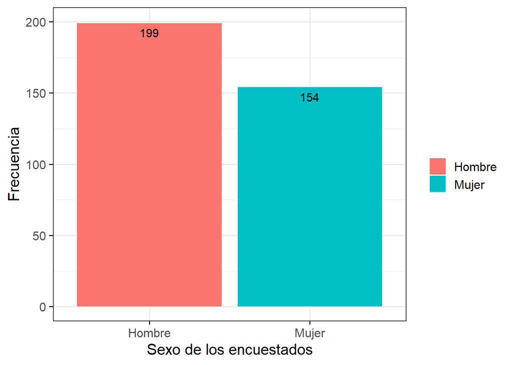

```r
Tabla <- DFN %>% group_by(Sexo) %>% summarise(Total=n())

ggplot(Tabla, aes(x = Sexo, y=Total,fill=Sexo) ) +
  geom_bar(width = 0.9, stat="identity",
           position = position_dodge()                 )+

  ylim(c(0,200))+
  labs(x="Sexo de los encuestados", y= "Frecuencia") +
  labs(fill = "")+

  geom_text(aes(label=Total), vjust=1.6, color="black",
              position = position_dodge(0.9),  size=4.0
            ) +

  theme_bw(base_size = 15)
```

*El presente gráfico de barra da representatividad a la variable categórica, donde encontramos la variable sexo en las columnas y la frecuencia en la fila formando una tabla de contingencia distinta las tablas de contingencia permiten poder observar variables categóricas de una o más, en el caso estamos evaluando el sexo.*

*Podemos extraer que de acuerdo a estas cifras hay ciertos factores, como es el caso que nuestro alcance de encuestas llego a mayormente a hombres, donde se debe a que directamente fue compartido a nuestros compañeros de la universidad*

### Ocupación

```r
mfv(DFN$Actualmente.eres, na_rm=TRUE)                     #MODA
```

```
## [1] "Estudiar"
```

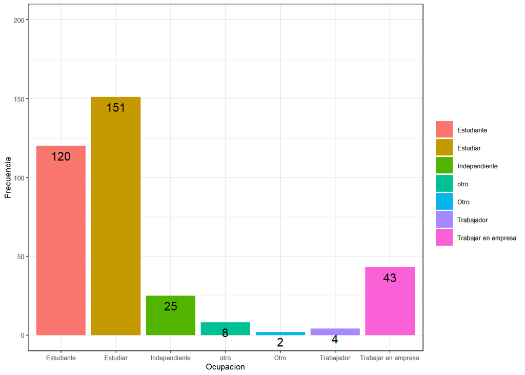

```r
Tabla <- DFN %>% group_by(Actualmente.eres) %>% summarise(Total=n())

ggplot(Tabla, aes(x =Actualmente.eres, y=Total,fill=Actualmente.eres) ) +
  geom_bar(width = 0.9, stat="identity",
           position = position_dodge()                 )+

  ylim(c(0,200))+
  labs(x="Ocupacion", y= "Frecuencia") +
  labs(fill = "")+

  geom_text(aes(label=Total), vjust=1.6, color="black",
              position = position_dodge(0.9),  size=4.0
            ) +

  theme_bw(base_size = 8)
```

### Lugar de vacunación

```r
mfv(DFN$Lugar_de_vacunacion , na_rm=TRUE)                     #MODA
```

```
## [1] "Lima Tradicional"
```

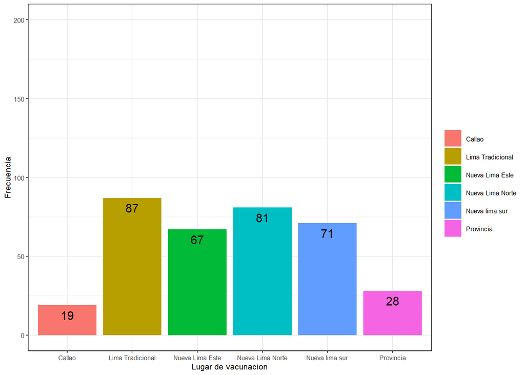

```r
Tabla <- DFN %>% group_by(Lugar_de_vacunacion) %>% summarise(Total=n())

ggplot(Tabla, aes(x =Lugar_de_vacunacion, y=Total,fill=Lugar_de_vacunacion) ) +
  geom_bar(width = 0.9, stat="identity",
           position = position_dodge()                 )+

  ylim(c(0,200))+
  labs(x="Lugar de vacunacion", y= "Frecuencia") +
  labs(fill = "")+

  geom_text(aes(label=Total), vjust=1.6, color="black",
              position = position_dodge(1),  size=4.0
            ) +

  theme_bw(base_size =8)
```

*El lugar de vacunación de la mayoría de los encuestados fue Lima Tradicional con 87 personas convirtiéndolo en dato unimodal, por otro parte, está Callao como el lugar de vacunación en menor cantidad*

### Tipo de vacuna

```r
mfv(DFN$Tipo_de_vacuna, na_rm=TRUE)        #MODA
```

```
## [1] "Pfizer"
```

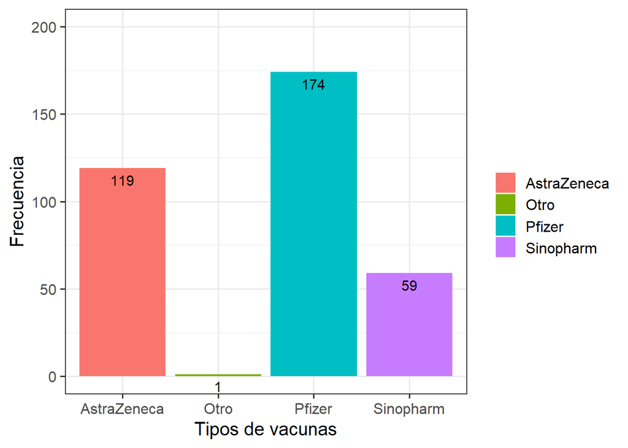

```r
Tabla <- DFN %>% group_by(Tipo_de_vacuna) %>% summarise(Total=n())

ggplot(Tabla, aes(x = Tipo_de_vacuna, y=Total,fill=Tipo_de_vacuna) ) +
  geom_bar(width = 0.9, stat="identity",
           position = position_dodge()                 )+

  ylim(c(0,200))+
  labs(x="Tipos de vacunas", y= "Frecuencia") +
  labs(fill = "")+

  geom_text(aes(label=Total), vjust=1.6, color="black",
              position = position_dodge(0.9),  size=4.0
            ) +

  theme_bw(base_size = 15)
```

*Entre los datos multimodales presenta una moda unimodal debido a que solo la moda del conjunto que representa la vacuna Pfizer se repite una única vez. También nos permite evidenciar que la mayoría en la unidad muestral el tipo de vacuna seria Pfizer, donde habría una covarianza con el grado de malestar corporal.*

*El coeficiente de sesgo que representa es = 0*

### Importancia

```r
mfv(DFN$Importancia, na_rm=TRUE) #MODA
```

```
## [1] "Si"
```

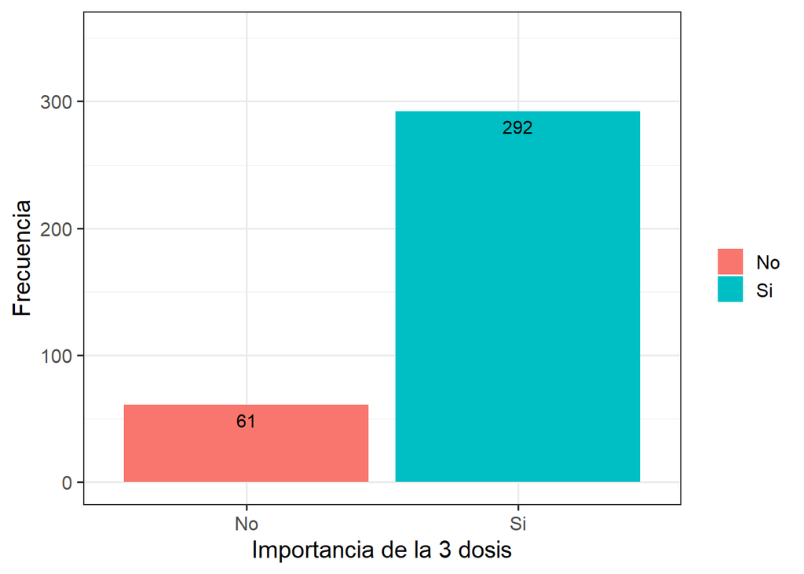

```r
Tabla <- DFN %>% group_by(Importancia) %>% summarise(Total=n())

ggplot(Tabla, aes(x = Importancia, y=Total,fill=Importancia) ) +
  geom_bar(width = 0.9, stat="identity",
           position = position_dodge()                 )+

  ylim(c(0,353))+
  labs(x="Importancia de la 3 dosis", y= "Frecuencia") +
  labs(fill = "")+

  geom_text(aes(label=Total), vjust=1.6, color="black",
              position = position_dodge(0.9),  size=4.0
            ) +

  theme_bw(base_size = 15)
```

### Seguridad

```r
mfv(DFN$Seguridad_de_la_dosis, na_rm=TRUE)                     #MODA
```

```
## [1] "Si"
```

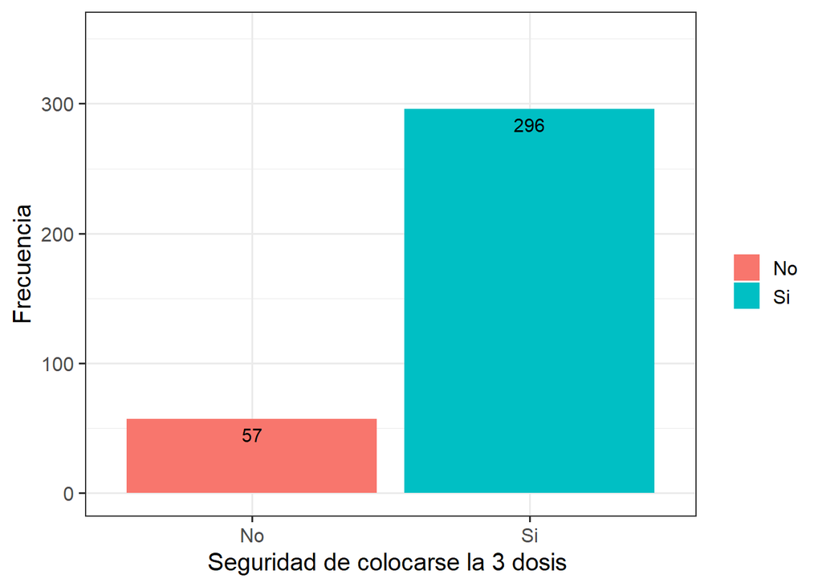

```r
Tabla <- DFN %>% group_by(Seguridad_de_la_dosis) %>% summarise(Total=n())

ggplot(Tabla, aes(x =Seguridad_de_la_dosis, y=Total,fill=Seguridad_de_la_dosis) ) +
  geom_bar(width = 0.9, stat="identity",
           position = position_dodge()                 )+

  ylim(c(0,353))+
  labs(x="Seguridad de colocarse la 3 dosis ", y= "Frecuencia") +
  labs(fill = "")+

  geom_text(aes(label=Total), vjust=1.6, color="black",
              position = position_dodge(1),  size=4.0
            ) +

  theme_bw(base_size =15)
```

*La preocupación respecto a la gran aceleración del virus y la gran reacción de la vacuna dando anticuerpos en nuestro sistema y fortaleciendo la inmunología genera una seguridad entre los ciudadanos, es por ello que se observa que en nuestro gobierno las medidas de aforo poco a poco más aumentando, dando como reflejo la responsabilidad con la vacunación de la tercera dosis y reduciendo la cifra de contagiados en el país.*

### Impedimento

```r
mfv(DFN$Impedimento, na_rm=TRUE)                     #MODA
```

```
## [1] "No"
```

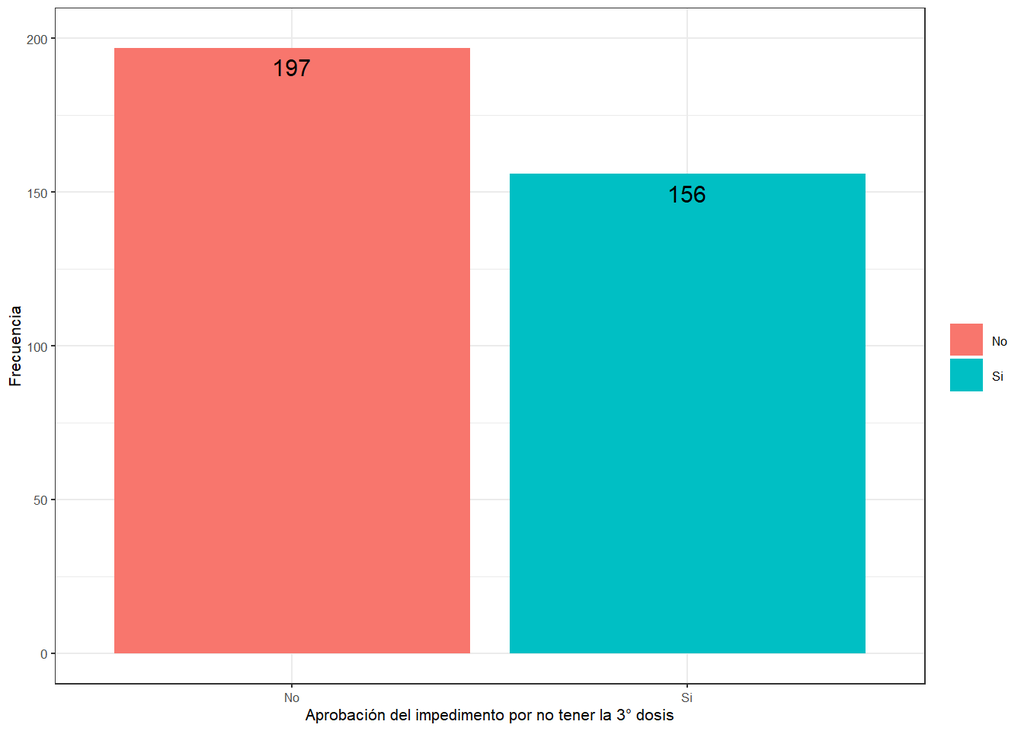

```r
Tabla <- DFN %>% group_by(Impedimento) %>% summarise(Total=n())

ggplot(Tabla, aes(x =Impedimento, y=Total,fill=Impedimento) ) +
  geom_bar(width = 0.9, stat="identity",
           position = position_dodge()                 )+

  ylim(c(0,200))+
  labs(x="Aprobación del impedimento por no tener la 3° dosis", y= "Frecuencia") +
  labs(fill = "")+

  geom_text(aes(label=Total), vjust=1.6, color="black",
              position = position_dodge(1),  size=4.0
            ) +

  theme_bw(base_size =8)
```